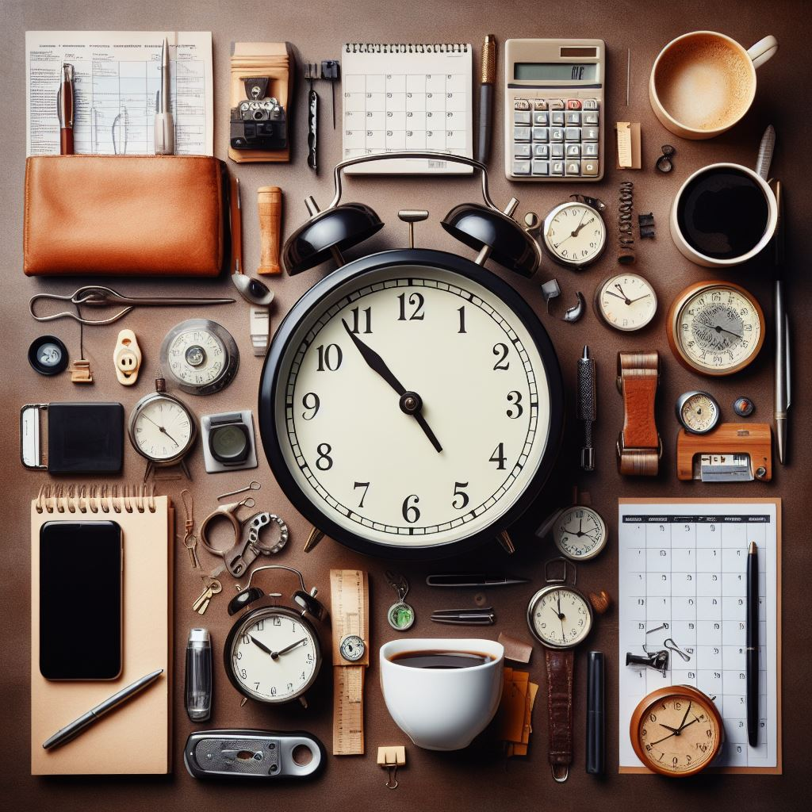

# Project and Time Management

Advice for managing your project, and your time

This may be your first time working on a scientific project or set of experiments at this kind of scale. The amount and variety of work required can seem overwhelming, especially if the topics and techniques are new. The need to keep a larger-level project and its goals in mind while focusing on a smaller subtask or single experiment can also be tricky, but does get easier with practice.

**Warning**

**Make sure you back up all of your project work.** IT issues such as computer failure are not considered grounds for an extension.

**Caution**

These articles come from external sources and are opinions. You will find a range of opinions within the group, as well as online. Some approaches are objectively better than others, and some are personal preference. Find what works for you, and **discussion is encouraged**!

## 1 Data and Project Management

These Notebooks on data and project management were prepared by Dr. Pritchard and Dr. Feeney for the 2022 session of BM432, but are also applicable to MSc projects.

- [Project management guidelines](https://sipbs-compbiol.github.io/BM432/notebooks/03-data_management_workshop.html)
  - [01-Data Analysis in the Research Cycle](https://sipbs-compbiol.github.io/BM432/notebooks/03-01-data_analysis.html)
  - [02-Data and Project Management](https://sipbs-compbiol.github.io/BM432/notebooks/03-02-project_management.html)
  - [03-Reproducibility, Replicability, and FAIR Guidelines](https://sipbs-compbiol.github.io/BM432/notebooks/03-03-reproducibility.html)
  - [04-Keeping a Lab Notebook to Document Your Project](https://sipbs-compbiol.github.io/BM432/notebooks/03-04-keeping_a_lab_notebook.html)
  - [05-Reference Management](https://sipbs-compbiol.github.io/BM432/notebooks/03-05-reference_management.html)
  - [06-How to Use Reference Management Software](https://sipbs-compbiol.github.io/BM432/notebooks/03-06-using_a_reference_manager.html)
- [NCSC advice for backing up your data](https://www.ncsc.gov.uk/collection/top-tips-for-staying-secure-online/always-back-up-your-most-important-data)

### 1.1 How Dr Pritchard backs up his data

**Tip**

The university has a [set of recommendations](https://www.strath.ac.uk/professionalservices/informationservices/it/saveshare/) for how you should save, share, and back up your data.

For each individual computer I:

- …work on data I cannot reconstruct easily using a cloud storage method that integrates with my filesystem.
  - I work on the data on the local machine, but changes are (automatically) propagated to a cloud service. This allows me to maintain a consistent state of my work across several machines at several sites, and automatically reproduces the material at several goegraphical locations in the cloud.
  - Ways to do this include [OneDrive](https://www.microsoft.com/en-gb/microsoft-365/onedrive/online-cloud-storage), [iCloud](https://www.icloud.com/), [DropBox](https://www.dropbox.com/), [GitHub](https://www.dropbox.com/), [GitLab](https://gitlab.com/users/sign_in), [BitBucket](https://bitbucket.org/) and so on
- …back up each computer to a local dedicated storage system, e.g. a [NAS (network-attached storage)](https://en.wikipedia.org/wiki/Network-attached_storage) with a high-availability file system (i.e. running a variant of RAID or similar)
  - This backup is run using an automated tool, such as Apple’s [Time Machine](https://support.apple.com/en-gb/HT201250), or [Carbon Copy Cloner](https://bombich.com/download)
- …additionally back up each computer to an external hard drive
  - I use at least two hard drives per machine, and I swap these between two distinct physical locations at regular intervals (usually weekly)
  - This backup is also run using an automated tool, such as Apple’s [Time Machine](https://support.apple.com/en-gb/HT201250), or [Carbon Copy Cloner](https://bombich.com/download)

## 2 Laboratory Notebooks: Advice

- [A Quick Guide to Organizing Computational Biology Projects](https://doi.org/10.1371/journal.pcbi.1000424)
  - *My favourite introduction to the topic. It clearly lays out a template and a rationale for each decision - LP*
- [How to Keep a Lab Notebook for Bioinformatic Analyses](https://blog.addgene.org/how-to-keep-a-lab-notebook-for-bioinformatic-analyses)
  - *A guest blog at AddGene which makes some choices I would question. They’re probably fine for one small project, but I’d worry about scaling up, and lack of clarity in the longer term - LP*
- [Ten Simple Rules for a Computational Biologist’s Laboratory Notebook](https://journals.plos.org/ploscompbiol/article?id=10.1371/journal.pcbi.1004385)
  - *Overall sound advice, but short on recommending specific solutions - LP*
- [10 File Management Tips to Keep Your Electronic Files Organized](https://www.liveabout.com/computer-file-management-tips-2948083)
  - *Good general advice, and not only for bioinformatics projects - LP*
- [How to keep a lab notebook](https://www.science.org/content/article/how-keep-lab-notebook)
  - *First-hand experience in quotes from a number of scientists. Learn from their fails - LP*
- [10 Tips For Organizing Your Lab Book](https://bitesizebio.com/11068/10-tips-for-organizing-your-lab-book/)
  - *Very lab-focused, but good general points - LP*

## 3 Time and Project Management: Advice

- [8 Time Management Tips for Students](https://summer.harvard.edu/blog/8-time-management-tips-for-students/)
  - *Really good general advice, from Harvard - LP*
- [Kanban boards](https://en.wikipedia.org/wiki/Kanban_board)
  - *Kanban is a flexible way to manage projects that allows for rearrangement and rescheduling in the middle of the work. It doesn’t require any particular tool or software (I used to use sticky notes), but Trello does a good job of this - LP*
- [Pomodoro Technique](https://en.wikipedia.org/wiki/Pomodoro_Technique)
  - *I use the Pomodoro technique (with BeFocused, see below) to help me focus when I need to get through long writing tasks. I find it most useful to avoid burning out on a large piece of work - LP*

## 4 Time and Project Management: Resources

- [Trello](https://trello.com/)
  - *A widely-used project management tool, but tailored towards teams. It probably does more than you need - LP*
- [Asana](https://asana.com/)
  - *Seems to be similar to Trello. I haven’t used it, myself - LP*
- [Benchling](https://www.benchling.com/)
  - *An electronic lab notebook platform that is widely used in industry. Academic use is free, and having it on your CV can be an advantage, so I’m told - LP*
- [Pomodoro Timer](https://pomofocus.io/)
  - *Free timer for Pomodoro. Just does the timing, which may be all you need - LP*
- [BeFocused](https://apps.apple.com/us/app/be-focused-focus-timer/id973130201)
  - *Pomodoro timer with additional project management and time categorisation features. It’s the tool I use - LP*
- [Forest](https://www.forestapp.cc/)
  - *A focusing app. I hear good things but I don’t use it - LP*
- [EverNote](https://evernote.com/)
  - *Note-taking app. I know people who love it, but it didn’t grab me - LP*